# CA1

Name: Pranjal Prathap Bavikai

Admin number: 2228396

Form Class: DIT/FT/2A/02

PDS Class: EL/EP0302/FT/04

CA1

# Title of Data Analysis

Which Flat Type in a Particular Town Offers the Most Advantageous Investment Returns for Current Flat Owners Over the Years?

# List of URLs of dataset

- https://data.gov.sg/dataset/resale-flat-prices
- https://data.gov.sg/dataset/median-rent-by-town-and-flat-type
- https://data.gov.sg/dataset/renting-out-of-flats
- https://data.gov.sg/dataset/school-directory-and-information

# Import libraries

```python
import numpy as np
import matplotlib.pyplot as plt
```

# Import data file

```python
resale_flat_prices = np.genfromtxt("./resale-flat-prices/resale-flat-prices-based-on-registration-date-from-jan-2017-onwards.csv",
                                   delimiter=',',
                                   names=True,
                                   dtype=('datetime64[M]', 'U30', 'U20', 'U5', 'U45', 'U30', int, 'U30', 'datetime64[Y]', 'U30', int))
median_rent_by_town_flat_type = np.genfromtxt("./median-rent-by-town-and-flat-type/median-rent-by-town-and-flat-type.csv",
                                              delimiter=',',
                                              names=True,
                                              dtype=('U30', 'U30', 'U10', int))
renting_out_of_flats = np.genfromtxt("./renting-out-of-flats/renting-out-of-flats.csv",
                                     delimiter=',',
                                     names=True,
                                     dtype=('datetime64[M]', 'U30', 'U5', 'U50', 'U20', int))
general_information_of_schools = np.genfromtxt("./school-directory-and-information/general-information-of-schools.csv",
                                               delimiter=',',
                                               names=True,
                                               dtype=('U60', 'U60', 'U60', 'U10', 'U10', 'U10', 'U40', 'U30', 'U20', 'U80', 'U50', 'U50', 'U50', 'U3', 'U3', 'U3', 'U3', 'U10', 'U10', 'U10'))
```

# Resale Flat Prices

```python
print("***** Resale Flat Prices *****")
print(f"There are {len(resale_flat_prices)} rows in the dataset")
print(f"There are {len(np.unique(resale_flat_prices['month']))} months of data from {np.min(resale_flat_prices['month'])} to {np.max(resale_flat_prices['month'])}.")
print(f"There are {len(np.unique(resale_flat_prices['flat_type']))} flat types in the dataset")
print()
print(f"The lowest resale price is ${np.min(resale_flat_prices['resale_price'])}")
print(f"The highest resale price is ${np.max(resale_flat_prices['resale_price'])}")
print(f"The average resale price is ${np.mean(resale_flat_prices['resale_price'])}")
print(f"The median resale price is ${np.median(resale_flat_prices['resale_price'])}")
print()
print(f"The average resale price of a Multi Generation flat is ${np.mean(resale_flat_prices['resale_price'][resale_flat_prices['flat_type'] == 'MULTI-GENERATION'])}")
print()
print(f"The average resale price of a 5-room flat is ${np.mean(resale_flat_prices['resale_price'][resale_flat_prices['flat_type'] == '5 ROOM'])}")
print()
print(f"The average resale price of a 4-room flat is ${np.mean(resale_flat_prices['resale_price'][resale_flat_prices['flat_type'] == '4 ROOM'])}")
print()
print(f"The average resale price of a 3-room flat is ${np.mean(resale_flat_prices['resale_price'][resale_flat_prices['flat_type'] == '3 ROOM'])}")
print()
print(f"The average resale price of a 2-room flat is ${np.mean(resale_flat_prices['resale_price'][resale_flat_prices['flat_type'] == '2 ROOM'])}")
print()
print(f"The average resale price of a 1-room flat is ${np.mean(resale_flat_prices['resale_price'][resale_flat_prices['flat_type'] == '1 ROOM'])}")
```

```
***** Resale Flat Prices *****
There are 154511 rows in the dataset
There are 77 months of data from 2017-01 to 2023-05.
There are 7 flat types in the dataset

The lowest resale price is $140000
The highest resale price is $1418000
The average resale price is $482780.4895573778
The median resale price is $450000.0

The average resale price of a Multi Generation flat is $821707.5

The average resale price of a 5-room flat is $577135.9156227539

The average resale price of a 4-room flat is $479907.7617915425

The average resale price of a 3-room flat is $338127.17520697525

The average resale price of a 2-room flat is $260289.47413441955

The average resale price of a 1-room flat is $196904.19672131148
```

# Nature Of The Dataset:

The dataset contains a total of 154511 rows of data. The data is relatively clean and well-formatted. However, there are a few peculiarities that should be noted.

I analyzed the dataset using the following steps:

1. I imported the data into a Python Numpy DataFrame.
2. I performed a statistical analysis of the data, including calculating the mean, of the resale prices by town, flat type, and other factors.
3. I created visualizations of the data, such as line chart, bar graph, pie chart and scatterplots.
4. I interpreted the results of the analysis to identify trends and patterns in the data.

# What is the distribution of the resale prices across different flat types?

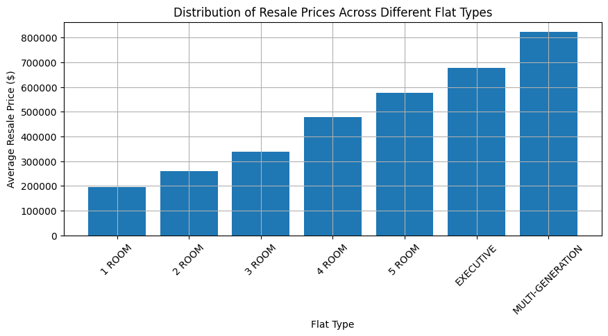

```python
# Extract flat type and average resale price
flat_types = np.unique(resale_flat_prices['flat_type'])
avg_resale_price = []
for flat_type in flat_types:
    avg_resale_price.append(np.mean(resale_flat_prices[resale_flat_prices['flat_type']==flat_type]['resale_price']))

# Plotting the graph
plt.figure(figsize=(10, 4))
plt.bar(flat_types, avg_resale_price)
plt.xlabel('Flat Type')
plt.ylabel('Average Resale Price ($)')
plt.title('Distribution of Resale Prices Across Different Flat Types')
plt.xticks(rotation=45)
plt.grid(True)
plt.show()
```

From the bar graph, it shows the Distribution of Resale Prices Across Different Flat Types. The highest average resale price for a flat would be multi-generation flats. The lowest average resale price for a flat would be 1 room flats. It is evident that there is a clear relationship between the number of rooms in different flat types and the average resale price. As the number of rooms increases, there is a corresponding upward trend in the average resale price.

It can also be seen that the median average resale price would be that of a 4 room flat hence a considerable option for purchasing a flat.

## Which flat type is sold the most?

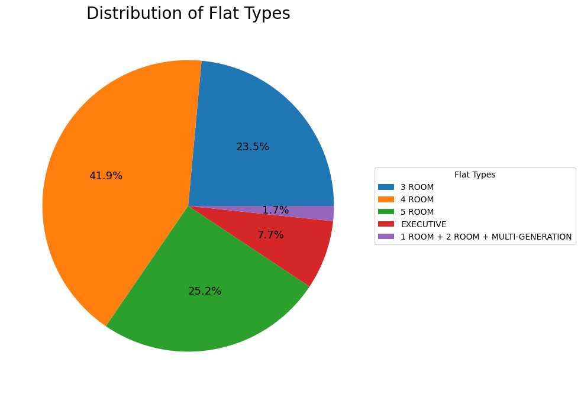

```python
room1_count = np.sum(resale_flat_prices['flat_type']=='1 ROOM')
room2_count = np.sum(resale_flat_prices['flat_type']=='2 ROOM')
room3_count = np.sum(resale_flat_prices['flat_type']=='3 ROOM')
room4_count = np.sum(resale_flat_prices['flat_type']=='4 ROOM')
room5_count = np.sum(resale_flat_prices['flat_type']=='5 ROOM')
executive_count = np.sum(resale_flat_prices['flat_type']=='EXECUTIVE')
mg_count = np.sum(resale_flat_prices['flat_type']=='MULTI-GENERATION')

room12mg_count = room1_count + mg_count + room2_count

sizes = [room3_count, room4_count, room5_count, executive_count, room12mg_count]

flat_type = np.unique(resale_flat_prices['flat_type'])

new_labels = []
for flat in flat_type:
    if flat == '1 ROOM':
        np.delete(flat, np.where(flat == '1 ROOM'))
    elif flat == '2 ROOM':
        np.delete(flat, np.where(flat == '2 ROOM'))
    elif flat == 'MULTI-GENERATION':
        continue
    else:
        new_labels.append(flat)
new_labels.append('1 ROOM + 2 ROOM + MULTI-GENERATION')

fig1,ax1 = plt.subplots(figsize=(8,8))
ax1.pie(sizes, autopct='%1.1f%%', textprops={'fontsize': 13})
plt.legend(new_labels,title="Flat Types",loc="center left",bbox_to_anchor=(1, 0.5))
plt.title("Distribution of Flat Types",fontsize=20)
plt.show()
```

From the pie chart, it shows the Distribution of Resale Flat Types. The majority of resale flats sold are 4 room flats with 41.9%. The least number of resale flats sold is the combination of 1 room, 2 room and multi generation flats all of which cumulatively account for 1.7%.

# What is the trend of the resale prices for 4 room flats across the months and years?

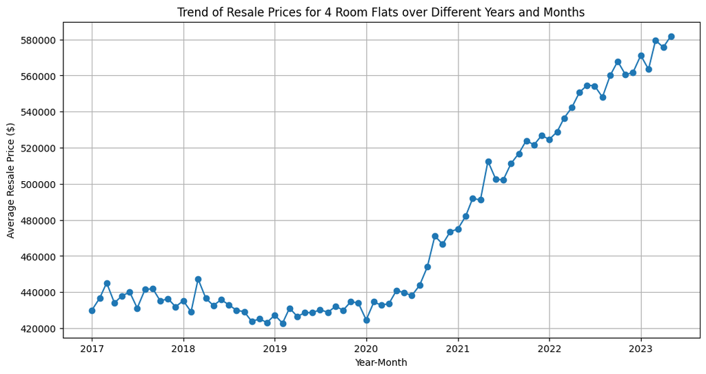

```python
# Filter the dataframe for '4 ROOM' flats
four_room_prices = resale_flat_prices[resale_flat_prices['flat_type'] == '4 ROOM']

#Extract month and the average resale price
months = np.unique(four_room_prices['month'])
avg_resale_price = []
for month in months:
    avg_resale_price.append(np.mean(four_room_prices[four_room_prices['month']==month]['resale_price']))

# Create the line plot
plt.figure(figsize=(12, 6))
plt.plot(months, avg_resale_price, marker='o', linestyle='-')
plt.xlabel('Year-Month')
plt.ylabel('Average Resale Price ($)')
plt.title('Trend of Resale Prices for 4 Room Flats over Different Years and Months')
plt.xticks(rotation=0)
plt.grid(True)
plt.show()
```

# How has lease commence date for 4 room flats affected the trend of the resale price?

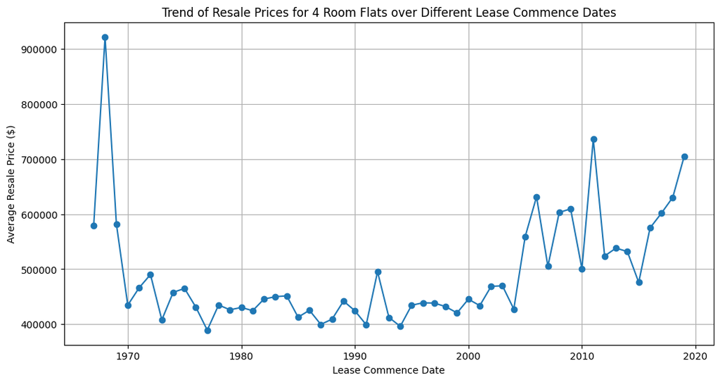

```python
# Filter the dataframe for '4 ROOM' flats
four_room_prices = resale_flat_prices[resale_flat_prices['flat_type'] == '4 ROOM']

# Extract the lease commence date and average resale price
lease_commence_date = np.unique(four_room_prices['lease_commence_date'])
avg_resale_price = []
for date in lease_commence_date:
    avg_resale_price.append(np.mean(four_room_prices[four_room_prices['lease_commence_date']==date]['resale_price']))

# Create the line plot
plt.figure(figsize=(12, 6))
plt.plot(lease_commence_date, avg_resale_price, marker='o', linestyle='-')
plt.xlabel('Lease Commence Date')
plt.ylabel('Average Resale Price ($)')
plt.title('Trend of Resale Prices for 4 Room Flats over Different Lease Commence Dates')
plt.xticks(rotation=0)
plt.grid(True)
plt.show()
```

From the line chart, it shows the Trend of Resale Prices for 4 Room Flats over Different Lease Commence Dates. The lowest average resale price would be that for lease commence date of 1977. The lighest average resale price would be that for lease commence date of 1968. It is evident that there is a clear relationship between the lease commence date and the average resale price from 2000 onwards. As the lease commence date increases, there is a corresponding upward trend in the average resale price from 2000 onwards.

# Which town offers the most advantageous investment returns for current flat owners ?

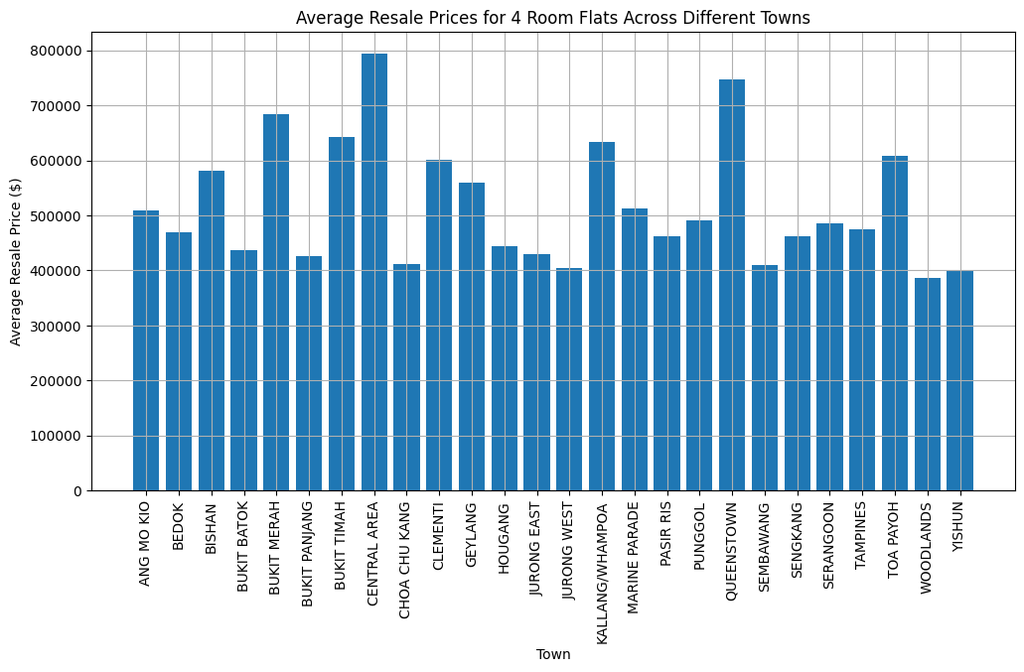

```python
# Filter the dataframe for '4 ROOM' flats
four_room_prices = resale_flat_prices[resale_flat_prices['flat_type'] == '4 ROOM']

# Extract the town and average resale price
town = np.unique(four_room_prices['town'])
avg_resale_price = []
for towns in town:
    avg_resale_price.append(np.mean(four_room_prices[four_room_prices['town']==towns]['resale_price']))

# Create the bar chart
plt.figure(figsize=(12, 6))
plt.bar(town, avg_resale_price)
plt.xlabel('Town')
plt.ylabel('Average Resale Price ($)')
plt.title('Average Resale Prices for 4 Room Flats Across Different Towns')
plt.xticks(rotation=90)
plt.grid(True)
plt.show()
```

From the bar graph, it shows the Average Resale Prices for 4 Room Flats Across Different Towns. It is highest in the central area with about nearly SGD 800,000. The lowest would be woodlands with slightly lower than SGD 400,000.

Since 4 room flats is the most preferred and central area has the highest average resale price.

# What would the trend of the resale prices for 4 room flats in central area across the months and years?

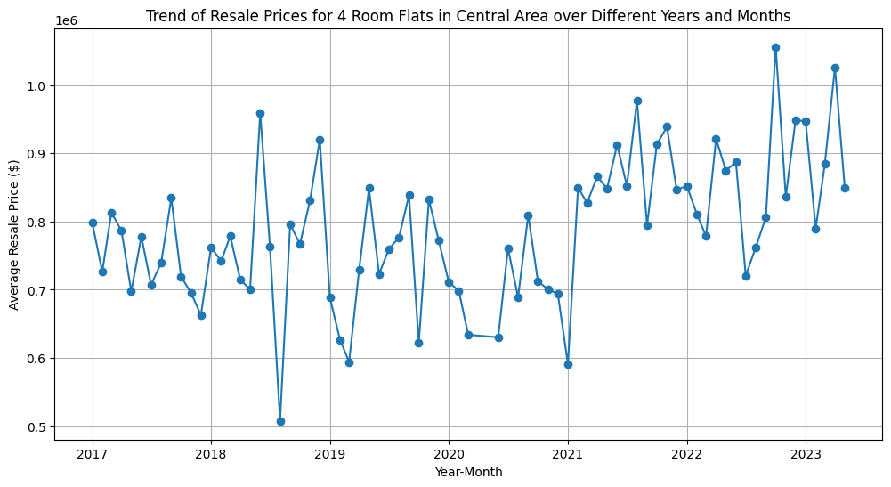

```python
# Filter the dataframe for '4 ROOM' flats in the CENTRAL AREA
four_room_prices_central = resale_flat_prices[(resale_flat_prices['flat_type'] == '4 ROOM') & (resale_flat_prices['town'] == 'CENTRAL AREA')]

#Extract month and the average resale price
months = np.unique(four_room_prices_central['month'])
avg_resale_price = []
for month in months:
    avg_resale_price.append(np.mean(four_room_prices_central[four_room_prices_central['month']==month]['resale_price']))

# Create the line plot
plt.figure(figsize=(12, 6))
plt.plot(months, avg_resale_price, marker='o', linestyle='-')
plt.xlabel('Year-Month')
plt.ylabel('Average Resale Price ($)')
plt.title('Trend of Resale Prices for 4 Room Flats in Central Area over Different Years and Months')
plt.xticks(rotation=0)
plt.grid(True)
plt.show()
```

From the line chart, it shows the Trend of Resale Prices for 4 Room Flats in Central Area over Different Years and Months. It is the highest on 2022 october with nearly SGD 1,100,000 and the lowest average resale price would be 2018 august with just slightly above SGD 500,000.

Since 4 room flats is the most preferred and central area has the highest average resale price.

# How has lease commence date for 4 room flats in central area affected the trend of the resale price?

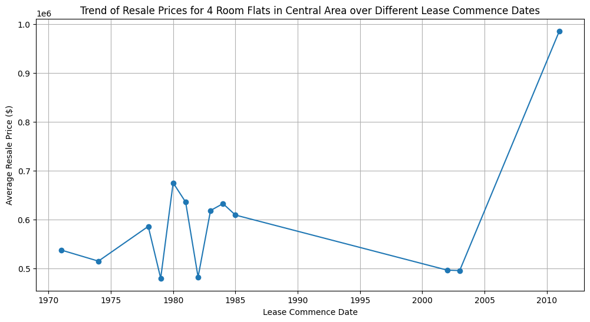

```python
# Filter the dataframe for '4 ROOM' flats in the CENTRAL AREA
four_room_prices_central = resale_flat_prices[(resale_flat_prices['flat_type'] == '4 ROOM') & (resale_flat_prices['town'] == 'CENTRAL AREA')]

# Extract the lease commence date and average resale price
lease_commence_date = np.unique(four_room_prices_central['lease_commence_date'])
avg_resale_price = []
for date in lease_commence_date:
    avg_resale_price.append(np.mean(four_room_prices_central[four_room_prices_central['lease_commence_date']==date]['resale_price']))

# Create the line plot
plt.figure(figsize=(12, 6))
plt.plot(lease_commence_date, avg_resale_price, marker='o', linestyle='-')
plt.xlabel('Lease Commence Date')
plt.ylabel('Average Resale Price ($)')
plt.title('Trend of Resale Prices for 4 Room Flats in Central Area over Different Lease Commence Dates')
plt.xticks(rotation=0)
plt.grid(True)
plt.show()
```

From the line chart, it shows the Trend of Resale Prices for 4 Room Flats in Central Area over Different Lease Commence Dates. It is highest during 2011 with nearly SGD 1,000,000 and the lowest during 1982 and 1979 with slightly below SGD 500,000. It is evident that there is a clear relationship between the lease commence date and the average resale price from 2003 onwards. As the lease commence date increases, there is a corresponding upward trend in the average resale price from 2003 onwards.

# How does storey range affect resale prices for 4 room flats in central area?

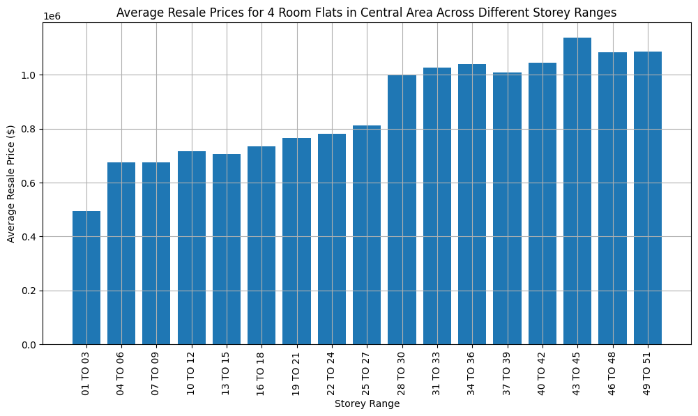

```python
# Filter the dataframe for '4 ROOM' flats in the CENTRAL AREA
four_room_prices_central = resale_flat_prices[(resale_flat_prices['flat_type'] == '4 ROOM') & (resale_flat_prices['town'] == 'CENTRAL AREA')]

# Extract the storey and average resale price
storey = np.unique(four_room_prices_central['storey_range'])
avg_resale_price = []
for storeys in storey:
    avg_resale_price.append(np.mean(four_room_prices_central[four_room_prices_central['storey_range']==storeys]['resale_price']))

# Create the bar chart
plt.figure(figsize=(12, 6))
plt.bar(storey, avg_resale_price)
plt.xlabel('Storey Range')
plt.ylabel('Average Resale Price ($)')
plt.title('Average Resale Prices for 4 Room Flats in Central Area Across Different Storey Ranges')
plt.xticks(rotation=90)
plt.grid(True)
plt.show()
```

# What is the most in-demand floor area for a 4 room flat in central area?

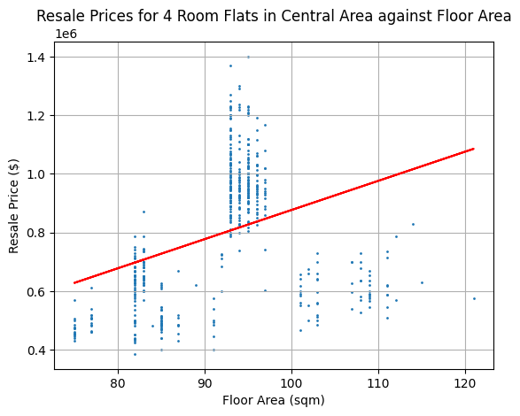

```python
# Filter the dataframe for '4 ROOM' flats in the CENTRAL AREA
four_room_prices_central = resale_flat_prices[(resale_flat_prices['flat_type'] == '4 ROOM') & (resale_flat_prices['town'] == 'CENTRAL AREA')]

# Extract the floor area and resale price
floor_area = four_room_prices_central['floor_area_sqm']
resale_price = four_room_prices_central['resale_price']

a,b = np.polyfit(floor_area, resale_price, 1)
plt.scatter(floor_area, resale_price,s=1)
plt.plot(floor_area, a*floor_area+b, color='red')
plt.title('Resale Prices for 4 Room Flats in Central Area against Floor Area')
plt.xlabel('Floor Area (sqm)')
plt.ylabel('Resale Price ($)')
plt.grid(True)
plt.show()
```

# Insights gained from analysing the data

I have analyzed the data in the CSV file "resale-flat-prices-based-on-registration-date-from-jan-2017-onwards". Here are some insights I have gained:

Based on my analysis, I have the following conclusions and recommendations:

- Buyers should also be aware of the fact that the resale price of a flat is likely to continue to increase over time. This is due to a number of factors, including rising demand, limited supply, and inflation.
- Flat owners that currently own a 4 room flat in the central area obtain the most advantageous investment returns because now they can sell their flats for much higher than they used to be valued.

Here are some additional insights that could be gained from the data:

- The resale price of a flat may also be affected by the age of the flat, the condition of the flat, and the surrounding neighborhood.
- Buyers may also be able to get a lower price for a flat if they are willing to buy a flat in a less desirable location or with fewer amenities.

# Median Rent By Town and Flat Type

```python
print("***** Median Rent By Town Flat Type *****")
print(f"There are {len(median_rent_by_town_flat_type)} rows in the dataset")
print(f"There are {len(np.unique(median_rent_by_town_flat_type['town']))} towns in the dataset")
print(f"There are {len(np.unique(median_rent_by_town_flat_type['flat_type']))} flat types in the dataset")
print()
print(f"The lowest median rent is ${np.min(median_rent_by_town_flat_type['median_rent'])}")
print(f"The highest median rent is ${np.max(median_rent_by_town_flat_type['median_rent'])}")
print(f"The average median rent is ${np.mean(median_rent_by_town_flat_type['median_rent'])}")
print()
print(f"The average median rent of a Executive flat is ${np.mean(median_rent_by_town_flat_type['median_rent'][median_rent_by_town_flat_type['flat_type'] == 'EXEC'])}")
print()
print(f"The average median rent of a 5-room flat is ${np.mean(median_rent_by_town_flat_type['median_rent'][median_rent_by_town_flat_type['flat_type'] == '5-RM'])}")
print()
print(f"The average median rent of a 4-room flat is ${np.mean(median_rent_by_town_flat_type['median_rent'][median_rent_by_town_flat_type['flat_type'] == '4-RM'])}")
print()
print(f"The average median rent of a 3-room flat is ${np.mean(median_rent_by_town_flat_type['median_rent'][median_rent_by_town_flat_type['flat_type'] == '3-RM'])}")
print()
print(f"The average median rent of a 2-room flat is ${np.mean(median_rent_by_town_flat_type['median_rent'][median_rent_by_town_flat_type['flat_type'] == '2-RM'])}")
print()
print(f"The average median rent of a 1-room flat is ${np.mean(median_rent_by_town_flat_type['median_rent'][median_rent_by_town_flat_type['flat_type'] == '1-RM'])}")
```

```
***** Median Rent By Town Flat Type *****
There are 11121 rows in the dataset
There are 53 towns in the dataset
There are 6 flat types in the dataset

The lowest median rent is $-1
The highest median rent is $4200
The average median rent is $964.2118514522075

The average median rent of a Executive flat is $825.5755124056095

The average median rent of a 5-room flat is $1786.2908796546142

The average median rent of a 4-room flat is $1855.2162891046387

The average median rent of a 3-room flat is $1272.27238403452

The average median rent of a 2-room flat is $46.34376686454398

The average median rent of a 1-room flat is $-1.0
```

# Nature Of The Dataset:

The dataset contains a total of 11121 rows of data. The data is relatively clean and well-formatted. However, there are a few peculiarities that should be noted.

- There are a few rows where the median rent is missing (i.e. "na", "-"). There is no data in the entire dataset which shows the median rent for 1 room flats.
- From the start of 2016-Q4 the town names have extra white space beside them hence making this dataset really hard to work with
- The median rent for some quarters is higher than the median rent for previous quarters. This may be due to a number of factors, such as an increase in demand for housing or an increase in the cost of construction.

I analyzed the dataset using the following steps:

1. I imported the data into a Python Numpy DataFrame.
2. I performed a statistical analysis of the data, including calculating the mean, of the resale prices by town, flat type, and other factors.
3. I created visualizations of the data, such as line chart, bar graph and histogram.
4. I interpreted the results of the analysis to identify trends and patterns in the data.

Since current flat owners of 4 room flats in central area posses the most advantages investment returns in terms of resale price of their flats. Lets explore more about the rental prices of these areas.

# How has various flat types affected the average median rent?

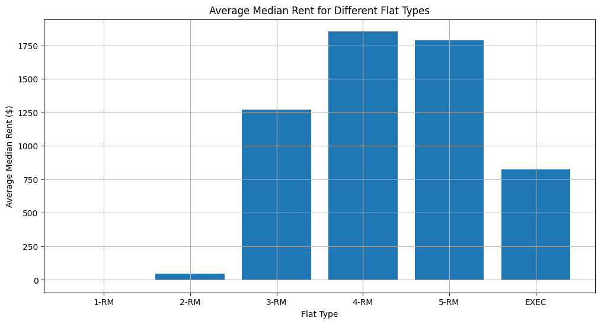

```python
# Extract median rent and flat type
flat_types = np.unique(median_rent_by_town_flat_type['flat_type'])
avg_median_rent = []
for flat in flat_types:
    avg_median_rent.append(np.mean(median_rent_by_town_flat_type[median_rent_by_town_flat_type['flat_type']==flat]['median_rent']))

# Create the bar plot
plt.figure(figsize=(12, 6))
plt.bar(flat_types, avg_median_rent)
plt.xlabel('Flat Type')
plt.ylabel('Average Median Rent ($)')
plt.title('Average Median Rent for Different Flat Types')
plt.xticks(rotation=0)
plt.grid(True)
plt.show()
```

# What is the trend of the Average Median Rent for 4 Room Flats in Central Area Across Different Quarters?

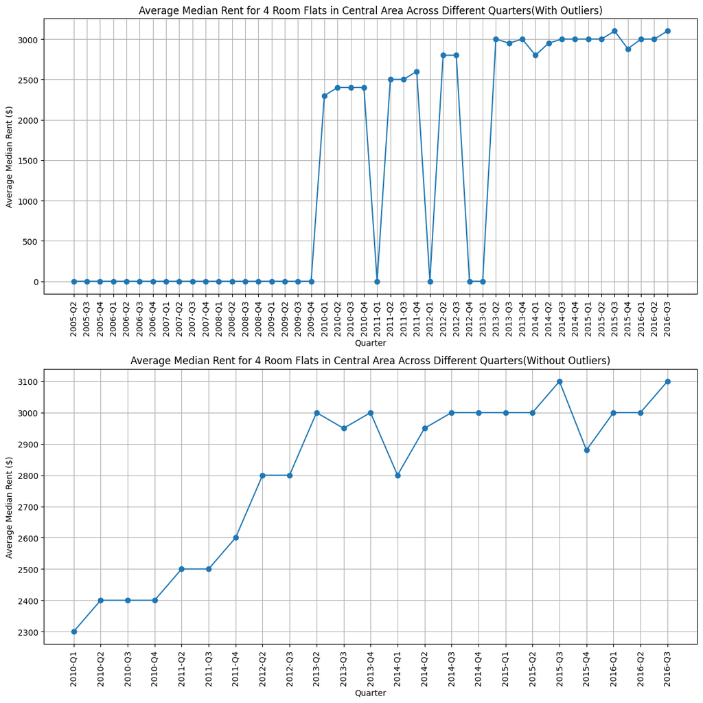

```python
# Filter the dataframe for '4 ROOM' flats in the CENTRAL AREA
four_room_rent_central = median_rent_by_town_flat_type[(median_rent_by_town_flat_type['flat_type'] == '4-RM') & (median_rent_by_town_flat_type['town'] == 'CENTRAL')]

# Extract the quarter and median rent
quarter = np.unique(four_room_rent_central['quarter'])
median_rent = []
for quarters in quarter:
    median_rent.append(np.mean(four_room_rent_central[four_room_rent_central['quarter']==quarters]['median_rent']))

# remove the first 19 data points
median_rent_cleaned = median_rent[19:]
quarter_cleaned = quarter[19:]

# remove the 5th, 9th, 12th and 13th data points
quarter_cleaned = np.delete(quarter_cleaned, [4, 8, 11, 12])
median_rent_cleaned = np.delete(median_rent_cleaned, [4, 8, 11, 12])

# Create the line plots using plt.subplot
plt.figure(figsize=(12, 12))

# First graph with uncleaned data
plt.subplot(2, 1, 1)
plt.plot(quarter, median_rent, marker='o', linestyle='-')
plt.xlabel('Quarter')
plt.ylabel('Average Median Rent ($)')
plt.title('Average Median Rent for 4 Room Flats in Central Area Across Different Quarters(With Outliers)')
plt.xticks(rotation=90)
plt.grid(True)

# Second graph with cleaned data
plt.subplot(2, 1, 2)
plt.plot(quarter_cleaned, median_rent_cleaned, marker='o', linestyle='-')
plt.xlabel('Quarter')
plt.ylabel('Average Median Rent ($)')
plt.title('Average Median Rent for 4 Room Flats in Central Area Across Different Quarters(Without Outliers)')
plt.xticks(rotation=90)
plt.grid(True)
# Adjust the spacing between subplots
plt.tight_layout()
plt.show()
```

# What is the distribution of median rent for 4 room flats as well as an in depth analysis of the distribution of median rent for 4 room flats in central areas?

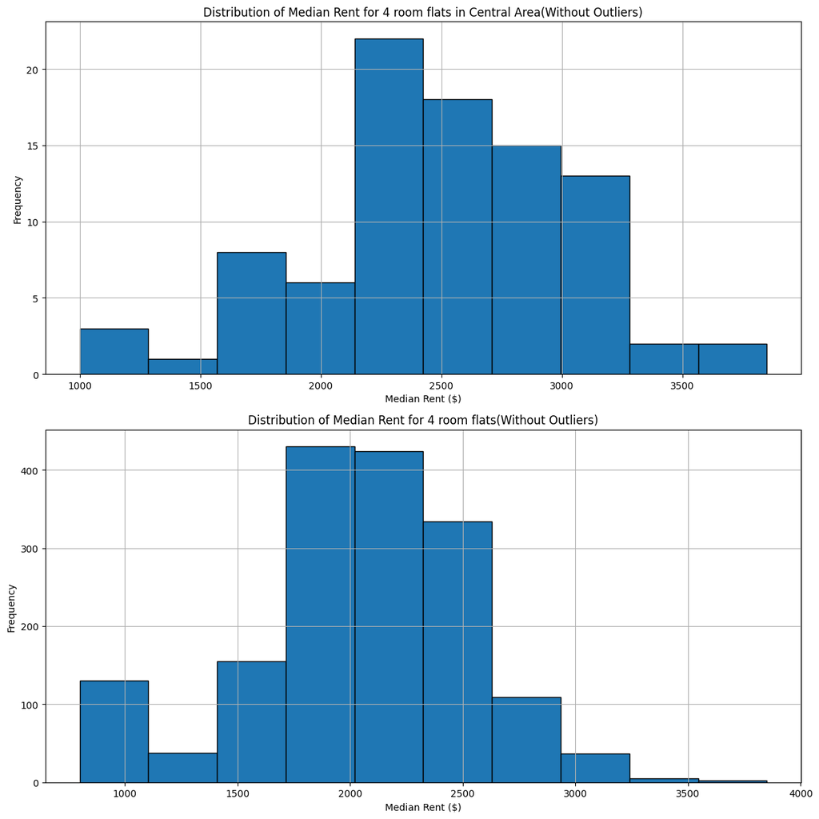

```python
# Filter the dataframe for '4 ROOM' flats in the CENTRAL AREA
four_room_rent_central = median_rent_by_town_flat_type[(median_rent_by_town_flat_type['town'] == 'CENTRAL') | (median_rent_by_town_flat_type['town'] == 'CENTRAL        ') & (median_rent_by_town_flat_type['flat_type'] == '4-RM')]['median_rent']
# Remove the outliers, elements with value -1
four_room_rent_central_cleaned = four_room_rent_central[four_room_rent_central != -1]

# Filter the dataframe for '4 ROOM' flats
four_room_rent = median_rent_by_town_flat_type[median_rent_by_town_flat_type['flat_type'] == '4-RM']['median_rent']
# Remove the outliers, elements with value -1
four_room_rent_cleaned = four_room_rent[four_room_rent != -1]

# Create the line plots using plt.subplot
plt.figure(figsize=(12, 12))

# 4 room flats graph in CENTRAL AREA
plt.subplot(2, 1, 1)
plt.hist(four_room_rent_central_cleaned, edgecolor="black")
plt.xlabel('Median Rent ($)')
plt.ylabel('Frequency')
plt.title('Distribution of Median Rent for 4 room flats in Central Area(Without Outliers)')
plt.grid(True)

# 4 room flats graph
plt.subplot(2, 1, 2)
plt.hist(four_room_rent_cleaned, edgecolor="black")
plt.xlabel('Median Rent ($)')
plt.ylabel('Frequency')
plt.title('Distribution of Median Rent for 4 room flats(Without Outliers)')
plt.grid(True)
# Adjust the spacing between subplots
plt.tight_layout()
plt.show()
```

In the first graph it can be observed that the highest frequency would be about 23 and median rent of about SGD 2250. The lowest frequency would be 1 for about SGD 1500.

# Insights gained from analysing the data

I have analyzed the data in the CSV file "median-rent-by-town-and-flat-type". Here are some insights I have gained:

- The average median rent for 4 room flats in the central area is significantly higher than the average median rent for other flat types. This suggests that there is a high demand for 4 room flats in the central area.
- The average median rent for 4 room flats has been increasing steadily over time. This suggests that the cost of living in the central area is increasing.
- The distribution of median rents for 4 room flats in the central area is skewed to the right. This suggests that there are a small number of very expensive 4 room flats in the central area, which is driving up the average median rent.

Based on my analysis, I have the following conclusions and recommendations:

- The high cost of renting a 4 room flat in the central area may make it difficult for some people to afford to live there.
- The increasing cost of living in the central area may lead to people moving to other areas of the city.
- Current owners of 4 room flats in the central area are able to sell their flats for a profit. The increasing prices of 4 room flats in the central area means that owners can sell their flats for a profit. This can be a great way to generate capital for other investments, such as buying a larger flat, investing in property development, or starting a business.
- They are able to charge higher rents. The high demand for 4 room flats in the central area means that owners can charge higher rents than they would be able to in other areas of the city. This can provide a significant source of income for owners, especially if they are renting out their flats to tenants.

# Renting Out Of Flats

```python
print("***** Renting Out Of Flats *****")
print(f"There are {len(renting_out_of_flats)} rows in the dataset")
print(f"There are {len(np.unique(renting_out_of_flats['rent_approval_date']))} months of data from {np.min(renting_out_of_flats['rent_approval_date'])} to {np.max(renting_out_of_flats['rent_approval_date'])}.")
print(f"There are {len(np.unique(renting_out_of_flats['flat_type']))} flat types in the dataset")
print()
print(f"The lowest monthly rent is ${np.min(renting_out_of_flats['monthly_rent'])}")
print(f"The highest monthly rent is ${np.max(renting_out_of_flats['monthly_rent'])}")
print(f"The average monthly rent is ${np.mean(renting_out_of_flats['monthly_rent'])}")
print(f"The median monthly rent is ${np.median(renting_out_of_flats['monthly_rent'])}")
print()
print(f"The average monthly rent of a Executive flat is ${np.mean(renting_out_of_flats['monthly_rent'][renting_out_of_flats['flat_type'] == 'EXECUTIVE'])}")
print()
print(f"The average monthly rent of a 5-room flat is ${np.mean(renting_out_of_flats['monthly_rent'][renting_out_of_flats['flat_type'] == '5-ROOM'])}")
print()
print(f"The average monthly rent of a 4-room flat is ${np.mean(renting_out_of_flats['monthly_rent'][renting_out_of_flats['flat_type'] == '4-ROOM'])}")
print()
print(f"The average monthly rent of a 3-room flat is ${np.mean(renting_out_of_flats['monthly_rent'][renting_out_of_flats['flat_type'] == '3-ROOM'])}")
print()
print(f"The average monthly rent of a 2-room flat is ${np.mean(renting_out_of_flats['monthly_rent'][renting_out_of_flats['flat_type'] == '2-ROOM'])}")
print()
print(f"The average monthly rent of a 1-room flat is ${np.mean(renting_out_of_flats['monthly_rent'][renting_out_of_flats['flat_type'] == '1-ROOM'])}")
```

```
***** Renting Out Of Flats *****
There are 85787 rows in the dataset
There are 28 months of data from 2021-01 to 2023-04.
There are 6 flat types in the dataset

The lowest monthly rent is $300
The highest monthly rent is $6500
The average monthly rent is $2400.4797346917367
The median monthly rent is $2300.0

The average monthly rent of a Executive flat is $2684.348207008965

The average monthly rent of a 5-room flat is $2618.8855856292066

The average monthly rent of a 4-room flat is $2498.208766010417

The average monthly rent of a 3-room flat is $2121.942914779162

The average monthly rent of a 2-room flat is $1700.9809725158561

The average monthly rent of a 1-room flat is $1383.3333333333333
```

# Nature Of The Dataset:

The dataset contains a total of 85787 rows of data. The data is relatively clean and well-formatted.

I analyzed the dataset using the following steps:

1. I imported the data into a Python Numpy DataFrame.
2. I performed a statistical analysis of the data, including calculating the mean, of the resale prices by town, flat type, and other factors.
3. I created visualizations of the data, such as line chart and bar graphs.
4. I interpreted the results of the analysis to identify trends and patterns in the data.

# What is the trend of the average monthly rent across different towns for 4 room flats

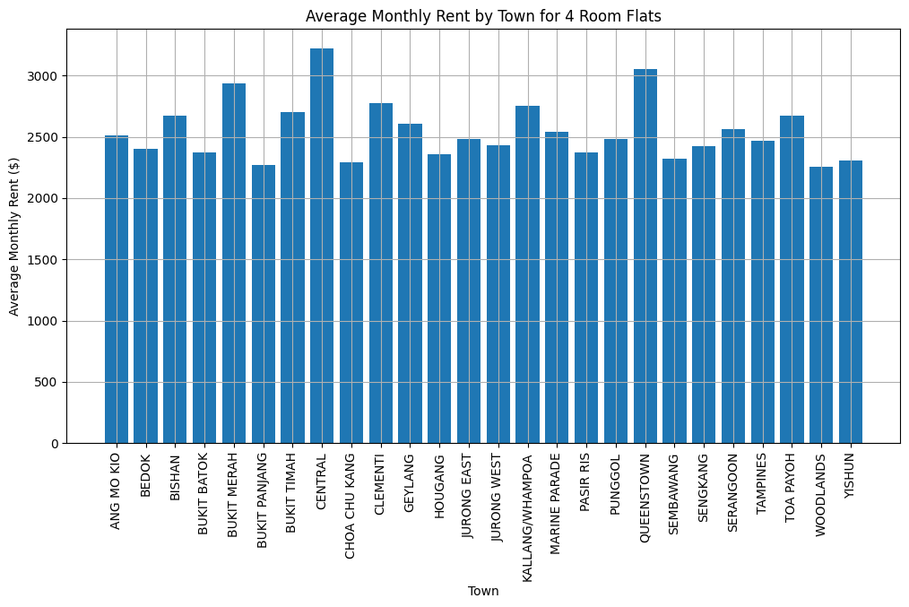

```python
# Filter the dataframe for '4 ROOM' flats
four_room_rent = renting_out_of_flats[renting_out_of_flats['flat_type'] == '4-ROOM']
# Extract town and the average monthly rental price
town = np.unique(four_room_rent['town'])
avg_monthly_rent = []
for towns in town:
    avg_monthly_rent.append(np.mean(four_room_rent[four_room_rent['town']==towns]['monthly_rent']))

# Create the line plot
plt.figure(figsize=(12, 6))
plt.bar(town, avg_monthly_rent)
plt.xlabel('Town')
plt.ylabel('Average Monthly Rent ($)')
plt.title('Average Monthly Rent by Town for 4 Room Flats')
plt.xticks(rotation=90)
plt.grid(True)
plt.show()
```

From the bar graph, it shows the Average Monthly Rent by Town for 4 Room Flats. It is the highest for central with about SGD 3100 and the lowest for woodlands with about SGD 2250.

# How has rent approval date affect the monthly rent ?

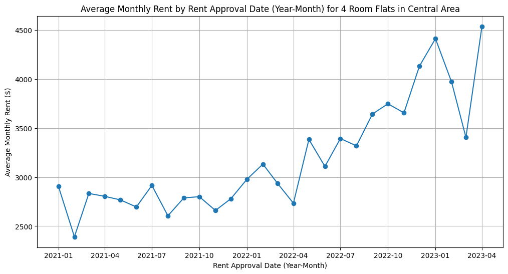

```python
# Filter the dataframe for '4 ROOM' flats and CENTRAL AREA
four_room_rent = renting_out_of_flats[renting_out_of_flats['flat_type'] == '4-ROOM']
four_room_rent_central = four_room_rent[four_room_rent['town'] == 'CENTRAL']
#Extract month and the average resale price
rent_approval_date = np.unique(renting_out_of_flats['rent_approval_date'])
avg_monthly_rent = []
for date in rent_approval_date:
    avg_monthly_rent.append(np.mean(four_room_rent_central[four_room_rent_central['rent_approval_date']==date]['monthly_rent']))

# Create the line plot
plt.figure(figsize=(12, 6))
plt.plot(rent_approval_date, avg_monthly_rent, marker='o', linestyle='-')
plt.xlabel('Rent Approval Date (Year-Month)')
plt.ylabel('Average Monthly Rent ($)')
plt.title('Average Monthly Rent by Rent Approval Date (Year-Month) for 4 Room Flats in Central Area')
plt.xticks(rotation=0)
plt.grid(True)
plt.show()
```

# How does flat type affect monthly rent in the central area?

[figure not shown]

```python
# Extract only central area data
central = renting_out_of_flats[renting_out_of_flats['town'] == 'CENTRAL']
flat_types = np.unique(central['flat_type'])
avg_monthly_rent = []
for flat in flat_types:
    avg_monthly_rent.append(np.mean(renting_out_of_flats[renting_out_of_flats['flat_type']==flat]['monthly_rent']))

# Create the bar plot
plt.figure(figsize=(12, 6))
plt.bar(flat_types, avg_monthly_rent)
plt.xlabel('Flat Type')
plt.ylabel('Average Monthly Rent ($)')
plt.title('Average Monthly Rent by Flat Type in Central Area')
plt.xticks(rotation=0)
plt.grid(True)
plt.show()
```

# Insights gained from analysing the data

I have analyzed the data in the CSV file "renting-out-of-flats". Here are some insights I have gained:

Based on my analysis, I have the following conclusions and recommendations:

- Based on the insights above, it can be concluded that the rental market for 4-room flats in Singapore is strong, with demand outstripping supply.
- As a result, landlords are able to command higher rents for their properties.
- This trend is likely to continue in the near future, as the population of Singapore continues to grow and the supply of housing remains limited.
- In order to make the most of this trend, landlords should consider upgrading their properties to executive flats, as these command higher rents.
- They should also consider renting out their properties in the Central Area, as this is the most expensive area in Singapore and rents are highest here.

# General Information of Schools

```python
print("***** General Information of Schools *****")
print(f"There are {len(general_information_of_schools)} rows in the dataset")
print(f"There are {len(np.unique(general_information_of_schools['school_name']))} schools in the dataset")
print()
print(f"There are {len(np.unique(general_information_of_schools[general_information_of_schools['zone_code'] == 'NORTH']['school_name']))} schools in the North zone")
print(f"There are {len(np.unique(general_information_of_schools[general_information_of_schools['zone_code'] == 'SOUTH']['school_name']))} schools in the South zone")
print(f"There are {len(np.unique(general_information_of_schools[general_information_of_schools['zone_code'] == 'EAST']['school_name']))} schools in the East zone")
print(f"There are {len(np.unique(general_information_of_schools[general_information_of_schools['zone_code'] == 'WEST']['school_name']))} schools in the West zone")
print()
print(f"There are {len(np.unique(general_information_of_schools[general_information_of_schools['mainlevel_code'] == 'PRIMARY']['school_name']))} primary schools")
print(f"There are {len(np.unique(general_information_of_schools[general_information_of_schools['mainlevel_code'] == 'SECONDARY']['school_name']))} secondary schools")
print(f"There are {len(np.unique(general_information_of_schools[general_information_of_schools['mainlevel_code'] == 'JUNIOR COLLEGE']['school_name']))} junior colleges")
print(f"There are {len(np.unique(general_information_of_schools[general_information_of_schools['mainlevel_code'] == 'MIXED LEVELS']['school_name']))} mixed level schools")
print(f"There are {len(np.unique(general_information_of_schools[general_information_of_schools['mainlevel_code'] == 'CENTRALISED INSTITUTE']['school_name']))} centralised institutes")
print()
print(f"There are {len(np.unique(general_information_of_schools[general_information_of_schools['type_code'] == 'GOVERNMENT SCHOOL']['school_name']))} government schools")
print(f"There are {len(np.unique(general_information_of_schools[general_information_of_schools['type_code'] == 'GOVERNMENT-AIDED SCH']['school_name']))} government-aided schools")
print(f"There are {len(np.unique(general_information_of_schools[general_information_of_schools['type_code'] == 'INDEPENDENT SCHOOL']['school_name']))} independent schools")
print(f"There are {len(np.unique(general_information_of_schools[general_information_of_schools['type_code'] == 'SPECIALISED INDEPENDENT SCHOOL']['school_name']))} specialised independent schools")
print(f"There are {len(np.unique(general_information_of_schools[general_information_of_schools['type_code'] == 'SPECIALISED SCHOOL']['school_name']))} specialised schools")
print()
print(f"There are {len(np.unique(general_information_of_schools[general_information_of_schools['nature_code'] == 'CO-ED SCHOOL']['school_name']))} co-ed schools")

boys_schools = general_information_of_schools[general_information_of_schools['nature_code'] == "BOYS' SCHOOL"]
number_of_boys_schools = len(np.unique(boys_schools['school_name']))
print(f"There are {number_of_boys_schools} boys schools")

girls_schools = general_information_of_schools[general_information_of_schools['nature_code'] == "GIRLS' SCHOOL"]
number_of_girls_schools = len(np.unique(girls_schools['school_name']))
print(f"There are {number_of_boys_schools} girls schools")
```

[output not shown]

# Nature Of The Dataset:

The CSV file "general-information-of-schools" contains data on general information of schools in Singapore. The data includes the following columns:

- School Name: The name of the school
- URL Address: The URL address of the school's website
- Address: The physical address of the school
- Postal Code: The postal code of the school
- Telephone Number: The telephone number of the school
- Fax Number: The fax number of the school
- Email Address: The email address of the school
- DGP Code: The DGP code of the school
- Zone Code: The zone code of the school
- Type Code: The type code of the school
- Nature Code: The nature code of the school
- Session Code: The session code of the school
- Main Level Code: The main level code of the school
- SAP Ind: Indicates whether the school is a SAP school
- Autonomous Ind: Indicates whether the school is an autonomous school
- Gifted Ind: Indicates whether the school is a gifted school
- IP Ind: Indicates whether the school is an IP school
- Mother Tongue 1 Code: The mother tongue language code of the first language taught at the school
- Mother Tongue 2 Code: The mother tongue language code of the second language taught at the school
- Mother Tongue 3 Code: The mother tongue language code of the third language taught at the school

The dataset contains a total of 346 rows of data. The data is relatively clean and well-formatted. However, there are a few peculiarities that should be noted.

- Some of the school names contain special characters, such as spaces and hyphens.

I analyzed the dataset using the following steps:

1. I imported the data into a Python Numpy DataFrame.
2. I performed a statistical analysis of the data, including calculating the mean, of the resale prices by town, flat type, and other factors.
3. I created visualizations of the data, such as bar graph, as well as a stacked bar graph.
4. I interpreted the results of the analysis to identify trends and patterns in the data.

# Does the location of schools affect the resale price and the rent prices of flats?

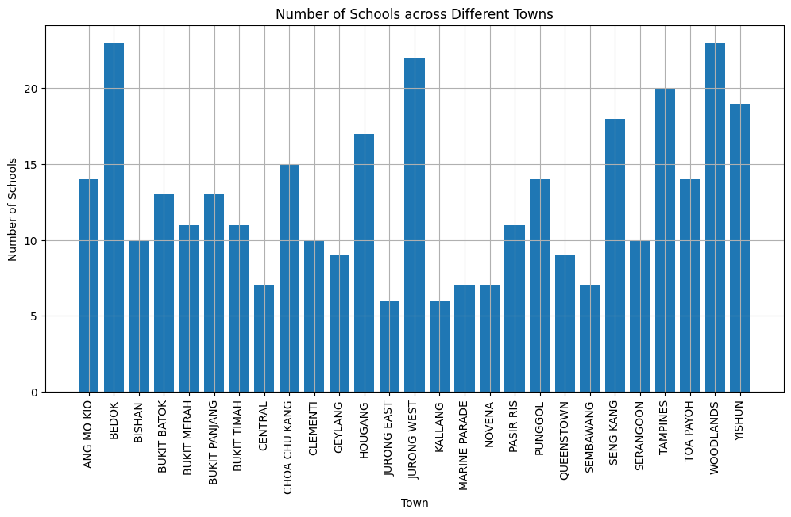

```python
# Extract the schools in central area
town = np.unique(general_information_of_schools['dgp_code'])
no_schools = []
for towns in town:
    no_schools.append(len(general_information_of_schools[general_information_of_schools['dgp_code']==towns]))

# Create the bar plot
plt.figure(figsize=(12, 6))
plt.bar(town, no_schools)
plt.xlabel('Town')
plt.ylabel('Number of Schools')
plt.title('Number of Schools across Different Towns')
plt.xticks(rotation=90)
plt.grid(True)
plt.show()
```

From the bar graph, it shows the Number of Schools across Different Towns. The lowest number of schools can be observed in jurong east and kallang with about 6 schools. The highest number of schools can be observed in bedok and woodlands with about 23 schools. Surprisingly even though central has the highest resale price for flats and a high monthly rental price, the number of schools available there is very less, about 7.

# What is the composition of schools in central ?

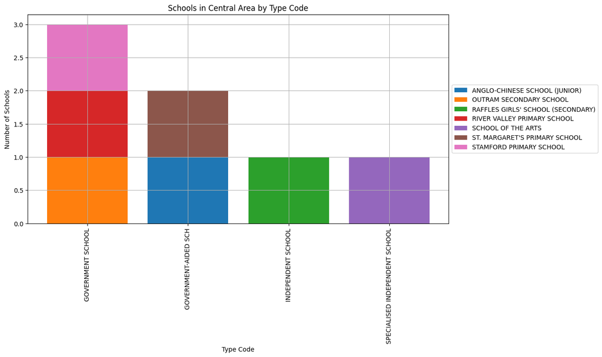

```python
# Extract the schools in central area
central = general_information_of_schools[general_information_of_schools['dgp_code'] == 'CENTRAL']
school_names = np.unique(central['school_name'])

# Group the schools by type code
type_code = np.unique(central['type_code'])
num_schools = []
for code in type_code:
    num_schools.append(len(central[central['type_code'] == code]))

# Create the stacked bar chart
plt.figure(figsize=(12, 6))
# Plot the bars for each school type
bottom = np.zeros(len(type_code))
for school_name in school_names:
    # filter dataset for current sch
    school_data = central[central['school_name'] == school_name]
    # store the counts for each type code
    counts = []
    for code in type_code:
        # filter dataset for current type code and get its count
        count = len(school_data[school_data['type_code'] == code])
        counts.append(count)
    plt.bar(type_code, counts, bottom=bottom, label=school_name)
    bottom += counts
plt.xlabel('Type Code')
plt.ylabel('Number of Schools')
plt.title('Schools in Central Area by Type Code')
plt.xticks(rotation=90)
plt.grid(True)
plt.legend(loc='center left', bbox_to_anchor=(1, 0.5))
plt.show()
```

# Insights gained from analysing the data

I have analyzed the data in the CSV file "general-information-of-schools". Here are some insights I have gained:

- The number of schools in a town is not always correlated with the resale price of flats or monthly rental price.
- There is a higher concentration of elite and well-known schools in central areas.
- The people living in central areas are typically of high socio-economic status.

Based on my analysis, I have the following conclusions and recommendations:

- Parents should consider the location of schools when choosing a place to live, but should not rely solely on the number of schools in a town.
- The government should consider building more schools in central areas to meet the needs of the growing population.
- More research could be done to understand the relationship between the location of schools and socio-economic status.

# Final Data Analysis Conclusion

In conclusion, the data analysis has shown that the most advantageous investment returns for current flat owners over the years are for 4 room flats in the central area. This is due to a number of factors, including the high demand for 4 room flats in the central area, the increasing prices of 4 room flats in the central area, and the high rental income that can be generated from 4 room flats in the central area.

The data analysis has also shown that the rental market for 4 room flats in Singapore is strong, with demand outstripping supply. As a result, landlords are able to command higher rents for their properties. This trend is likely to continue in the near future, as the population of Singapore continues to grow and the supply of housing remains limited.

In order to make the most of this trend, landlords should consider upgrading their properties to executive flats, as these command higher rents. They should also consider renting out their properties in the Central Area, as this is the most expensive area in Singapore and rents are highest here.

Parents should consider the location of schools when choosing a place to live, but should not rely solely on the number of schools in a town. The government should consider building more schools in central areas to meet the needs of the growing population. More research could be done to understand the relationship between the location of schools and socio-economic status.